# Financial Snapshot

Personal Wealth Overview — September 2026

Published

September 23, 2026

## Key Metrics

US Net Worth

As of Sep 21, 2026

Combined Net Worth

Includes Colombian assets

$7,488

Monthly Income

Guaranteed / permanent

$8,315

Monthly Spending

12-month recurring avg

−$827

Net Monthly Cash Flow

Funded by liquid reserve

37+ mos

Liquid Runway

$310K ÷ $8,315/mo

## Balance Sheet

Account Balances — September 21, 2026

|  | Account | Balance |
| --- | --- | --- |
| Checking/Savings |  |  |
|  | Wealthfront Cash Account | $153,492 |
|  | MassMutual - Annuities and Insurance Checking | $147,304 |
|  | Chase checking | $6,534 |
|  | BOA Savings | $1,307 |
|  | BOA Checking | $848 |
|  | Chase Savings | $528 |
| Subtotal | — | $310,013 |
| Credit Card |  |  |
|  | Hilton Honors AMEX 1009 | −$362 |
|  | Chase Amazon Visa 5154 | −$1,517 |
|  | Chase Marriott Bonvoy | −$1,706 |
|  | Citi /AAdvantage Executive World Elite Mastercard | −$8,136 |
| Subtotal | — | −$11,720 |
| Investment |  |  |
|  | Wealthfront Individual Bond Ladder | $103,287 |
|  | Wealthfront Joint Automated Investing Account | $80,619 |
|  | Kenneth's TODI Fidelity Go | $252 |
|  | Kenneth's Trad IRA Fidelity Go | $71 |
|  | Kenneth's Rollover IRA Fidelity Go | $13 |
|  | Resurety Stock | $0 |
|  | SEP-IRA | −$25 |
| Subtotal | — | $184,217 |
| Other Asset |  |  |
|  | Hawthorne home | $125,000 |
|  | Aircraft loan | $93,206 |
| Subtotal | — | $218,206 |
| NET WORTH | — | $700,715 |

[figure not shown]

## Income and Spending

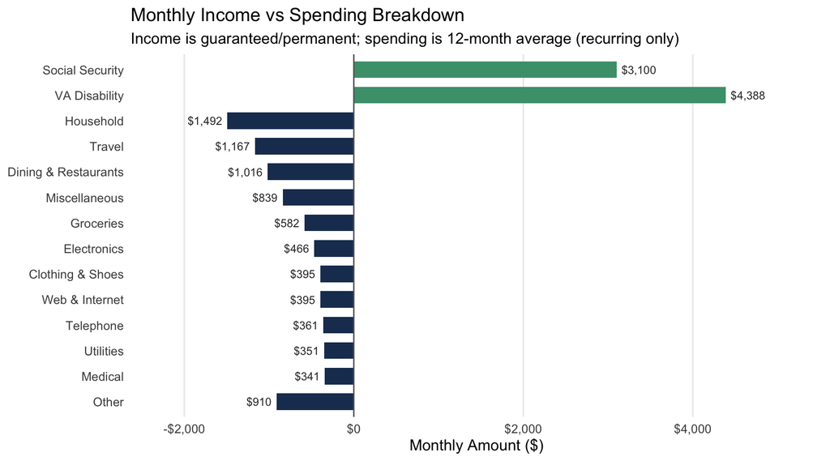

**Cash flow note:** Monthly income ($7,488) falls $827 short of recurring spending ($8,315). The $5,200/month invested via Wealthfront is drawn from the $310K liquid reserve — it is *relocation of assets*, not a cash surplus. The reserve provides 37+ months of runway at current burn and 50+ months without the investment contributions.

Major One-Time Purchases

Sep 2025 – Aug 2026 (transactions > $1,000)

| Date | Payee | Category | Amount |
| --- | --- | --- | --- |
| Feb 19, 2026 | Autolarte Itagui Col | Household | $23,914 |
| Jun 12, 2026 | American Nails | Fitness-Personal Care | $10,300 |
| Oct 10, 2025 | WINDSTAR CRUISE RESERV SEATTLE WA | Travel | $9,719 |
| Nov 29, 2025 | American Airlines | Travel | $9,406 |
| Nov 03, 2025 | Oceania Cruises | Travel | $6,434 |
| Jul 31, 2026 | Withdrawal | Miscellaneous Expenses | $5,000 |
| Mar 24, 2026 | Nustep Llc Plymouth MI | Household | $4,970 |
| Oct 02, 2025 | SP ANKER SOLIX ONTARIO CA | Dining-Restaurants | $3,581 |
| Feb 18, 2026 | Autolarte X9 | Gasoline-Fuel | $2,729 |
| Feb 18, 2026 | Autolarte Itagui Col | Household | $2,729 |
| Aug 25, 2026 | Wompi Sas Medellin Col | Dining-Restaurants | $2,502 |
| Jul 06, 2026 | Remitly United S PAYMENTS XX4058 ID: XX1988 | Travel | $2,500 |

*These large one-time items ($23.9K Colombia car, $9.7K Windstar cruise, $9.4K American Airlines, $6.4K Oceania cruise, $5K NuStep equipment) added ~$6,700/month on top of the recurring baseline and are not included in the $8,315/month recurring figure.*

## Asset Allocation

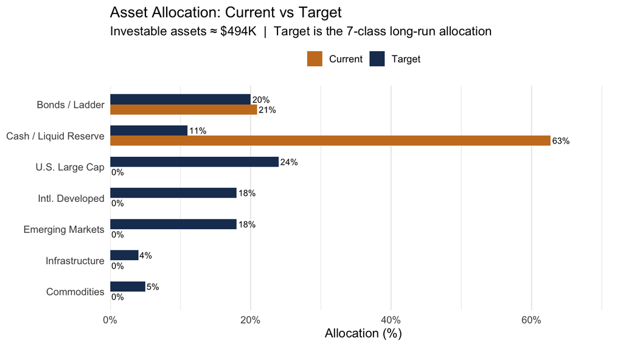

## Currency Exposure

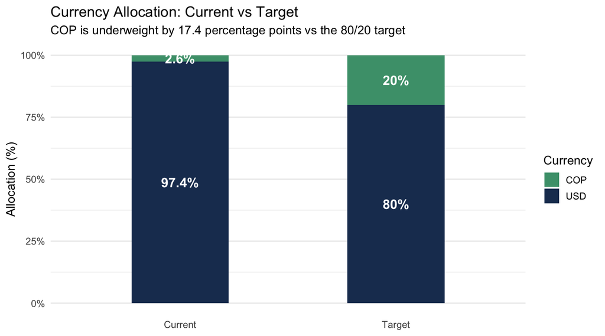

The 80/20 USD/COP target is set to hedge currency risk while keeping the bulk of the portfolio in the more liquid USD market. Closing the 17.4pp COP gap requires approximately $62K in new COP-denominated income-generating investments (CDTs, TES bonds).

## 5-Year Net Worth Projection

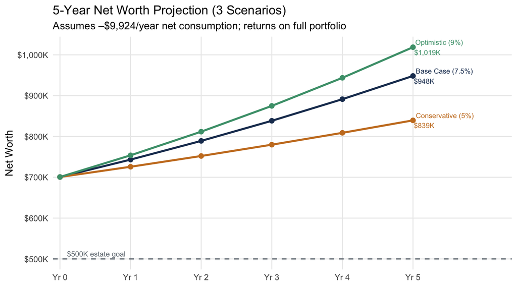

Projected Net Worth by Scenario

| Scenario | Year 1 | Year 3 | Year 5 |
| --- | --- | --- | --- |
| Base Case (7.5%) | $743,345 | $838,435 | $948,325 |
| Conservative (5%) | $725,827 | $779,880 | $839,473 |
| Optimistic (9%) | $753,855 | $874,914 | $1,018,745 |

*Data source: Banktivity QIF export (Sep 21, 2026); 12-month transaction analysis (Sep 2025–Aug 2026). Projections are illustrative and do not guarantee future results.*

> **Disclaimer:** This is research and analysis only, not personalized financial advice. Consult a qualified financial advisor before making investment decisions.